# Networks $\times$ Extremes Reading Group

Clement Lee

2021-11-11 (Thu)

# Background

- Directed networks here
- Preferential attachment model:
  - Nodes join the network one by one, bringing in new edges
  - $\Pr($existing node $i$ gets an edge$)~\propto~$ current degree of $i$
  - In-/total degree captures the rich-gets-richer effect

# Simulated network

- Size according to in-degree

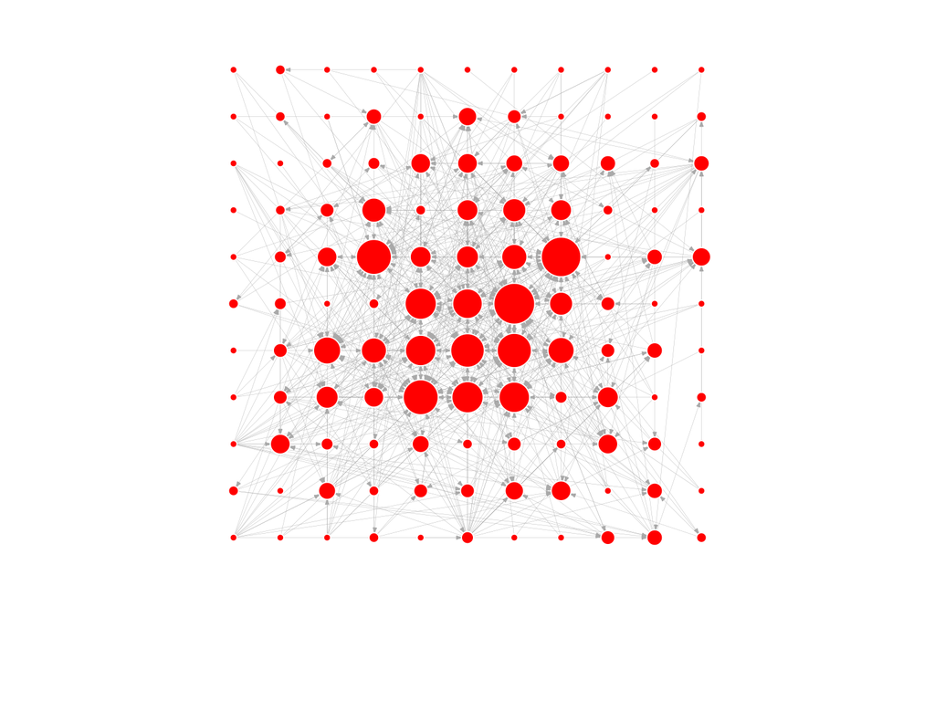

# Marginal distribution

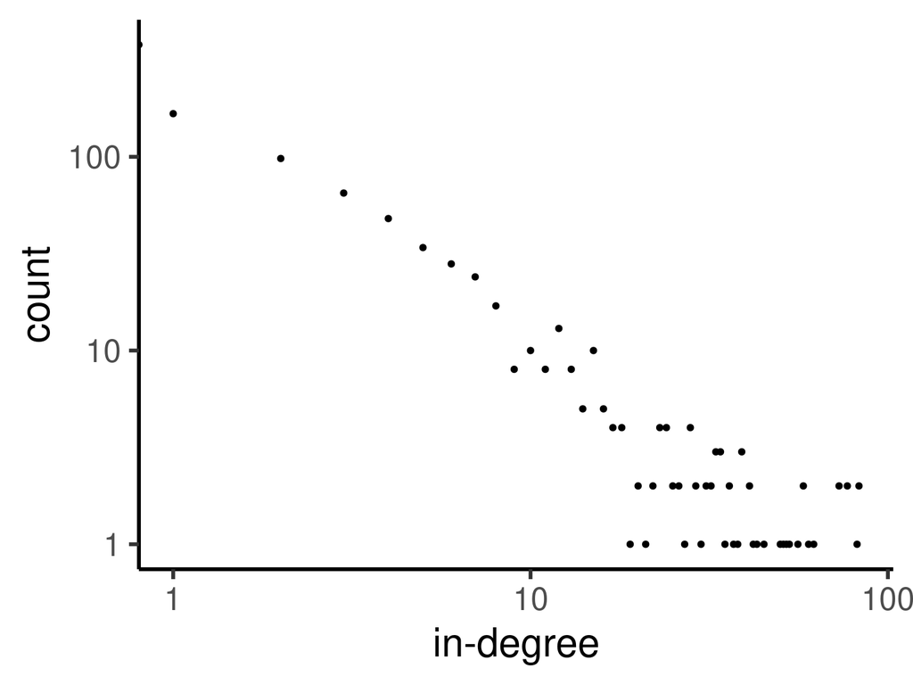

# Why?

- Easy to simulate from and fit to data
- In-degrees of empirical networks seem to follow the “power law”
  - Essentially the (non-generalised) Pareto distribution
  - Some argue otherwise (e.g. Broido and Clauset, 2018)
- Power law adequate? Not today’s scope

# Making the model more realistic

- $\Pr($existing node $i$ gets an edge$)~\propto~$ current degree of $i$ + $\boldsymbol{\delta}$
  - A positive probability of getting connected even if the node has no in-degre to start with
  - Level the playing field
- Reciprocity parameter $\boldsymbol{\rho}$
  - So far only either $A\rightarrow B$ or $B\rightarrow A$, but not both $\quad\Rightarrow\quad$ reciprocity $=0$
  - Empirical networks usually show high reciprocity
  - E.g. Instagram: if $A$ follows $B$, $B$ is more likely to follow $A$ back
  - $\rho$ affects how the in-degrees & out-degrees are correlated

# Joint distribution

- Same simulated network with 0 reciprocity

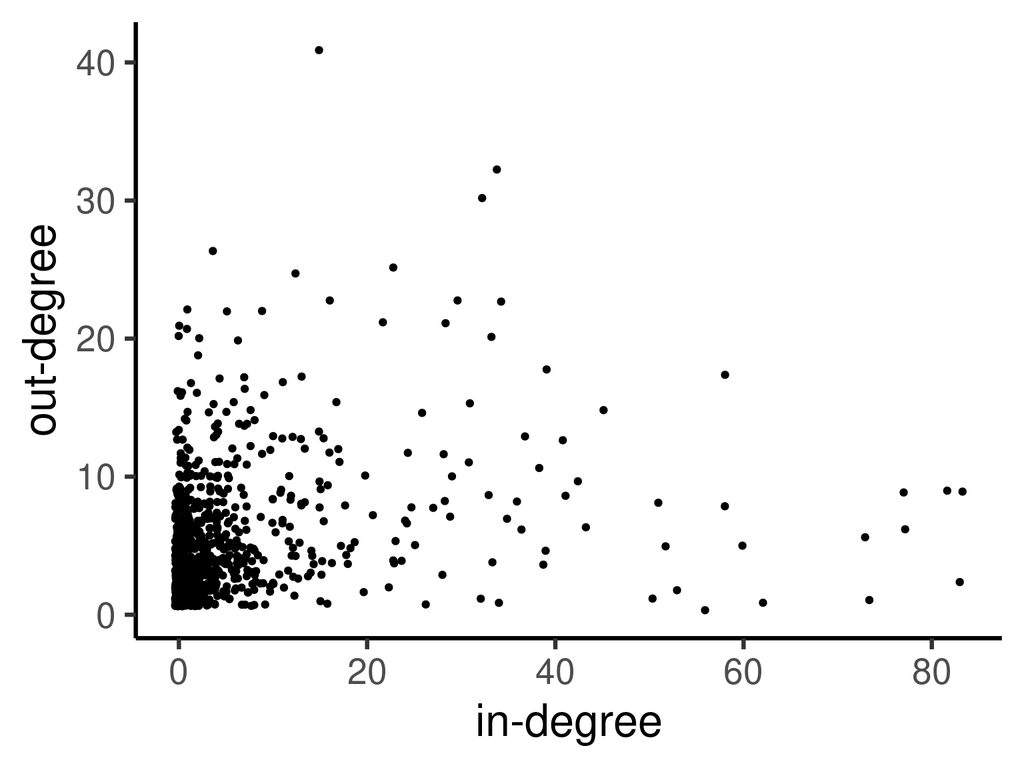

# Wang & Resnick (2021)

How does incorporating reciprocity in the preferential attachment model affect the in- & out-degrees?

1. What is their limiting (marginal) distribution?
2. What is their limiting joint distribution?
3. Are they asymptotically independent / dependent?

# Summary

- A relatively restrictive preferential attachment model even with reciprocity
  - Possibly for the theoretical derivations
- Turning the process of preferential attachment into a **multitype branching process with immigration**
- Using results developed for branching process to arrive at the limiting distributions of in- & out-degrees
  - Thus answering the questions they set out

# Model set up

1. Start with node 1 with a self-loop
2. Node $n+1$ joins when there are $n$ nodes in the network
3. With probability $\alpha$, there is an edge from node $n+1$ to an existing node
   - The node is chosen with probability $~\propto~$ their current in-degree $+~\delta$
   - With probability $\rho$, reciprocity happens i.e. an edge from the chosen node to $n+1$ is created
   - With probability $1-\rho$, reciprocity doesn’t happen
4. With probability $\gamma(=1-\alpha?)$, there is an edge from an existing node to node $n+1$
   - The node is chosen with probability $~\propto~$ their current out-degree $+~\delta$
   - With probability $\rho$, reciprocity happens i.e. an edge from $n+1$ to chosen node is created
   - With probability $1-\rho$, reciprocity doesn’t happen

# Converting to branching processes

- An in-degree $~\Leftrightarrow~$ a type 1 particle
- An out-degree $~\Leftrightarrow~$ a type 2 particle
- A node joins $~\Leftrightarrow~$ immigration event
  - Node $n+1$ joins at time $T_{n}$
- Creation of new edge $~\Leftrightarrow~$ death of existing particle & birth of new particle(s)
- While a type 1 particle can give birth to a type 2 particle, births of new type 1 particles must come with it $~\Leftrightarrow~$  
  While an in-degree can lead to a new out-degree, there must be a new in-degree first

# Converting to branching processes (cont’d)

- The existing node that connects with node $n+1$ $~\Leftrightarrow~$ $J_{n+1}$
- Reciprocity occurs when node $n+1$ joins $~\Leftrightarrow~$ $R_{n+1}$
- The evolution of the in- & out-degree of node $k$ $~\Leftrightarrow~$ $\boldsymbol{\xi}_{1,\delta}(\cdot)$
- The allocation of new edge(s) from node $n+1$ depends only on current in- & out-degrees $~\Leftrightarrow~$  
  The branching process is Markovian

# Connecting the two formally

- The collection of the branching processes $\left\{\boldsymbol{\xi}^{*}_\delta(T_n):n\geq0\right\}$
  - Before node $n+1$ arrives, $\boldsymbol{\xi}_{n+1},\delta(\cdot)$ is set to $(0,0)$
- The collection of in- & out-degree sequences $\boldsymbol{D}(n):=\left((D_1^{in}(1), D_1^{out}(1)), \ldots, (D_1^{in}(n), D_1^{out}(n)), (0,0), \ldots\right)$
- Theorem 2: The two have the same distributions
  - Any result for $\left\{\boldsymbol{\xi}^{*}_\delta(T_n):n\geq0\right\}$ can be used for the in- & out-degree sequences

# Result 1 / Theorem 4

- When there are $n$ nodes in the network, the in-degree of node $\omega$, rescaled by $n$ raised to a certain power, converges to a finite random variable $L_\omega$, as $n\rightarrow\infty$.
- Similar for the out-degree
- $n$ raised to a certain power – power law?
  - This power is a function of the parameters $(\alpha,\gamma,\rho,\delta)$
  - We will come back to this
- Special case: when $\alpha=1$
  - Nodes selected only according to in-degrees
  - Reciprocity only from existing node to new node
  - The rescaled out-degree converges to $\rho~L_\omega$

# Result 2 / Theorem 5

- Joint degree counts
  - Joint distribution of in- & out-degree in a different way
- $N_{m,l}(n)$: the number of nodes with $m$ in-degree & $l$ out-degree when there are $n+1$ nodes in the network
  - $N_{m,l}(n)/n$: Joint empirical pmf of $(m, l)$
- The first line of (3.10) not explicitly simplified, but leads to next result

# Result 3 / Theorem 6

- The in- & out-degrees are jointly regularly varying
- Index $(1+\rho+\delta)/\lambda_1$
  - Echoing theorem 4?
- Special case: when $\alpha=1$, $\lambda_1=1$
  - MRV with index $1+\rho+\delta$
- Asymptotic dependence
  - Question: Even when $\rho=0$?

# Full asymptotic dependence

# Simulation & Application

# Some thoughts

- Model quite restrictive & not very realistic
- Asymptotic dependence even if there’s no reciprocity
- Only one edge is added at each immigration
  - Presumably derivations are far more challenging when bringing in multiple edges & sampling without replacement
- No connecting between existing nodes
  - They did mention this in extensions